# Inside Out

Ananya Jain, Mansi Agarwal, Saravana Chilamakuri

13/10/2021

## Introduction

Our research question draws from a [previous project](https://elijah-samuel.github.io/voyant_project/) that found Alcott’s work to be more heavily populated with things that characterise the indoors, whereas Twain’s work was characterised by the outdoors. These findings were in line with the notion that women writing in the 19th century were more concerned with the domestic space as opposed to men who occupied themselves with more important things. While we know what space male and female authors occupied, we don’t necessarily know the sentiment surrounding that space. This paper is a step in that direction. It attempts to unpack the sentiment surrounding the indoor and outdoor space in the works of Louisa May Alcott and Mark Twain. It’s also useful in studying whether sentiment around indoor and outdoor functions as a binary. One might expect a positive portrayal of the indoor space to coincide with a negative portrayal of the outdoor space, and vice versa. While the results of a comparison between Twain and Alcott alone cannot be extrapolated to all the authors of that time, it is still useful as preliminary results can motivate studies at a larger scale and answer questions previously unanswered.

## Research Hypothesis

Given that Louisa May Alcott tends to write more intensely about the indoor space, as opposed to Mark Twain, who writes more about the outdoors, we expect sentiment to be positive around the indoor space in Alcott’s work and the outdoor space in Twain’s work, and negative in the outdoor space in Alcott’s work and the indoor space in Twain’s work.

## Corpus Description

It’s also interesting to note that given the gender identities of the two authors, the indoor and outdoor space tends to imply multifarious gender roles for each of them. While the domestic space can act as a refuge for women, the outdoors can do the same for men of that time. Virginia Woolf’s *Room of One’s Own* is a seminal work, which talks about the importance of solitary space for women, acting as a catapult for creativity and imagination, whereas a lack of ‘one’s own’ space curbs the same. On the contrary, the overwhelming number of works about the adventures of men in the wild, including *Tom Sawyer, Robinson Crusoe, Gulliver* amongst many, act as their source of free-spirited inspiration. This intuitively affects the sentiments surrounding the indoor and outdoor space for men and women, which we intend to explore through our project.

## Summary

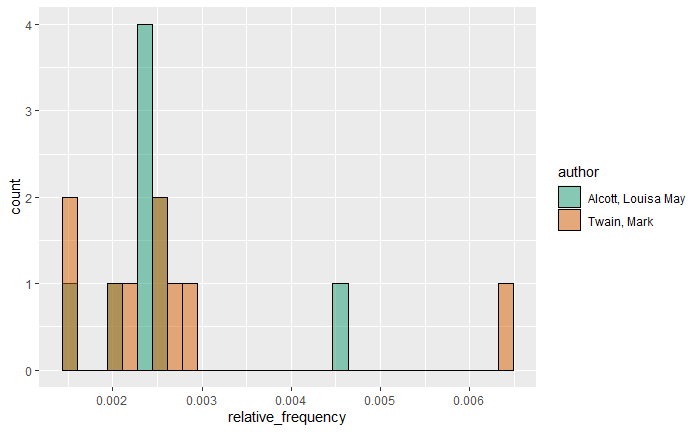

The contrast between usage of domestic and outdoor words is communicated through the graph below. It seems that Alcott is slightly more interested in the domestic space and Twain is slightly more interested in the outdoor space. Although there is not a dramatic difference, it sets us up to explore the sentiment around the two lexicons, given each author’s affiliation to write about the said spaces.

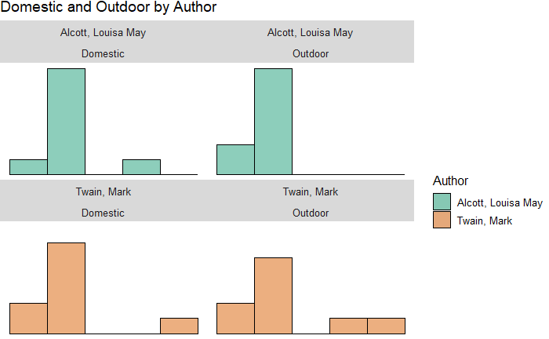

## Data Visualization 1 - Sentiment Analysis

After importing and cleaning the texts from gutenberg, we unnest the text to analyze the frequency of certain keywords in the text. We then convert the text into a set of sentences to analyze the sentiment of text around both indoor and outdoor spaces based on the predefined lexicon we have created. For this, we use the bing lexicon which characterises words into positive and negative sentiment, and tallies the total sentiment in the concepts. We then unnest these sentences into words and remove all the stop words to ensure that the results are not skewed one way or another. We then create a table with sentences of the texts having a positive or a negative sentiment attached to them. This is then used to give each sentence a count listing the total number of positive and negative sentiments. Then an aggregate sentiment is determined for each title written by Twain and Louisa.

Below is a numerical overview of the distribution of sentiment in the works of the two authors, taken together. Twain tends to write negatively about both the domestic and outdoor space. Louisa tends to write positively about the domestic space and is mixed in her sentiment around the outdoor space, where some works tend to be positive overall and others tend to be negative.

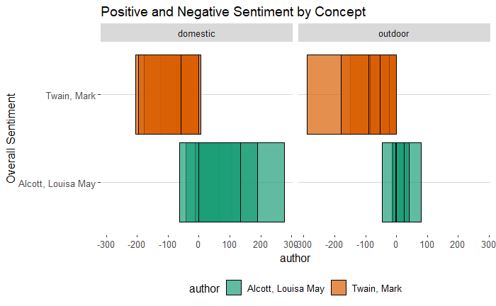

We break down sentiment by individual works of the authors in the graph below. All of Twain’s works, except for “Tom Sawyer: Abroad”, are associated with a negative sentiment around the domestic space. As for the outdoors, it is portrayed negatively too, with no exceptions. While Twain seems to be writing negatively overall, it is interesting to see how the intensity of negativity around the domestic and the outdoor space move relative to each other, as we move from one book to another. If the intensity of negative sentiment around the domestic space increases, that around the outdoor space decreases, and vice versa. While it is tempting to deduce a pattern from such an observation, it is not without its problems and shortcomings. The most glaring is the problem of absolute versus relative. The value shown is an aggregate of the sentiments surrounding concepts in the works. Thus, in addition to the sentiment, the value is influenced by, both, the choice of lexicon and the length of the books, giving us reason to be cautious in our analysis.

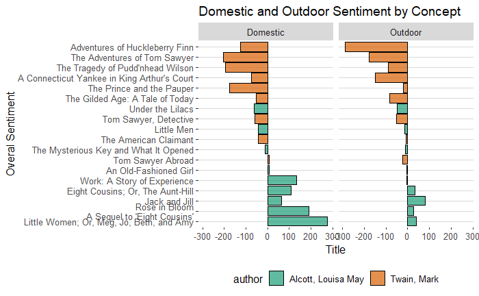

## Data Visualization 2 - NER

To further understand the sentiments surrounding locations, we used the ‘Natural Language Processing (NLP)’ and ‘Named Entity Recognition (NER)’ tools. Since the bag-of-words approach takes away a lot from the understanding of a text, we chose the NLP and NER approaches to do a more complex analysis of our corpus. We carried out the process on the ‘NRC’ lexicon, specifically for ‘locations’ in order to see: which locations are surrounded with the most emotional words, which places have the most positive and negative sentiments surrounding them, and whether Alcott or Twain writes more emotionally about space.

Our intuition behind using this tool was two-fold. Firstly, our primary lexicon for domestic and outdoor spaces considers material objects like ‘bed’, ‘sofa’, etc. for indoors and ‘sea’, ‘hills’, etc. for outdoors. However, the NER tool focuses on cities, states, countries and even street names. This aids our understanding of sentiments around locations, in a larger context. Secondly, considering the results of our primary sentiment analysis revealed that Twain’s overarching writing surrounding space is negative, whereas the contrary is true for Alcott, we used the NER tool to strengthen that result.

The process we followed included importing the data, cleaning it through R as well as manually, in order to remove several overlaps, and then processing them to produce visualizations for the locations and surrounding sentiments. This proved to be a highly tedious process, as we went down from 250,000 entries to about 3,500 entries through the filtering process; and after multiple trial and errors arrived at our clean data. This data, however, still possesses inconsistencies, which we elaborate on in the reflection section.

### Locations with most Positive emotions for Alcott and Twain

[interactive chart not shown]

### Locations with most Negative emotions for Alcott and Twain

[figure not shown]

The two data visualizations show the locations with highest positive and negative emotions that both Alcott and Twain write about. We observe that Twain dominates the emotional space in terms of locations, for both positive and negative emotions. The sentiment of trust dominates the positive emotions, with some cities being collocated with joy and anticipation as well. The sentiments of sadness, disgust and fear dominate the negative space.

Both Alcott and Twain talk positively of the USA. Twain further writes positively about major east and west coast cities of the USA like New York and Washington, as well as England. For Alcott, the second most positively talked about location surprisingly turns up to be China. On a deeper manual analysis of the same, we inspected the usage of China in the sentences for Alcott, and understood the context to not be of the space, but that of china vases, dish sets, closet, etc. While it skews our location analysis, it does reflect on Alcott being an upper-middle class woman and her association of positive sentiments with domestic materials.

Looking at the highest negative emotions, Twain associates feelings of disgust, sadness and fear with smaller US states and its cities concentrated in the middle eastern part of America. An outlier here is Chile, which on further manual sentence-wise analysis is a flaw of old English usage in Twain’s works, wherein ‘Chilen’ is used to refer to children.

While Twain dominates both emotional spheres, the fact that the most negative emotional collocations are more diverse (includes different states like Arkansas, Mississippi, Massachusetts) compared to the positive emotional collocations, strengthens the first data visualization, which indicated Twain’s writing tends to be on the negative side. Other possible reasons as to why the visualizations sway more towards Twain could also be a testament to Twain’s works being more outdoors-y than Alcott’s, wherein they refer to different locations in a higher frequency than Alcott.

## Conclusion

We find proof for a part of our hypothesis - that Alcott writes positively about the domestic space and Twain writes negatively about the domestic space. However, we don’t find a contrast in sentiment between the two spaces. It is not the case that a positively depicted outdoor space implies a negatively depicted indoor space, as one might expect. In fact, it seems to be that the overall direction of sentiment stays the same irrespective of space. Twain, who writes negatively about the domestic space also writes negatively about the outdoor space, suggesting that he writes negatively overall. This finding makes sense given his works occupy themes such as exploitation, slavery and surival. Alcott, who writes positively about the domestic space does write positively about the outdoor space overall, however, it is with a reduced intensity. Our findings can also be suggestive of not just appropriate spaces that women’s writing could occupy but also appropriate sentiment with which they could write about them.

## Reflection

Our research is, primarily, influenced and limited by our choice of lexicon. This impacts our study in a number of ways. First, some words cannot be completely classified as indoor or outdoor. “Water”, for example, can be associated with a river and a jug. Similarly, “wild”, although associated with the outdoors, can also be used to describe a person’s behaviour. Second, it may be possible that words that we have intuitively placed in the lexicon are not being used in the concept of space at all. For example, “chair” could be a position/office as much as a piece of furniture. Third, and common to digital studies of literary texts, the mention of a word does not imply its physical existence. Considering our research deals with the concept of physical space, this is a significant limitation. Moreover, different authors use different words. The words an author uses to describe the domestic space might be vastly different from what another uses, given the difference in socio-economic backgrounds. A domestic space doesn’t have to necessarily be populated with goods of domestic use to be domestic. A more populated space might reflect a more privileged domestic space, but a sparsely populated one is domestic nonetheless. However, a proxy lexicon takes lack of domestic objects to mean lack of domestic space, which biases the study. This manual creation of the lexicon also poses a problem when interpreting relative frequencies of words used, for the reasons outlined above.

The sentiment analysis of these works also relies heavily on the predefined lexicons available. We can not with a high degree of certainty say that the ‘bing’ or ‘NRC’ lexicons are an accurate reflection of the sentiment the author meant to attach to the respective words. Another shortcoming we encountered while conducting sentiment analysis was the flaw of assigning quantitative values to qualitative features.

The NER process, as mentioned before, was tedious as well as time consuming. Cleaning the data and scaling up the NER process for about 20 books with several character and location names, manual removal of them becomes reiterative and prone to error. Additionally, words like ‘Washington’ are locations, but also characters in the works of these authors, which also skews the sentiment analysis. There are certain unique constraints which we faced, for example: China is identified as a place in the NER process, although in Alcott’s works most of the references to China are in terms of ‘china vases’ and ‘china closet’. For Twain, Chile was not a reference to a place but a misconstrued interpretation of old English words by the software. Therefore, there are many ways in which computers lack in their reading of a text, which we were able to experience on a closer manual analysis of its creation of datasets.